# Week 5 Recitation

Chris

9/25/2019

# Sampling

Lets load a data set. This is the expression of three genes from a group of cells in a single-cell experiment.

```r
example.expression.data <- read.delim("Week_4_Example.tsv")
```

Lets do some basic analysis of this data

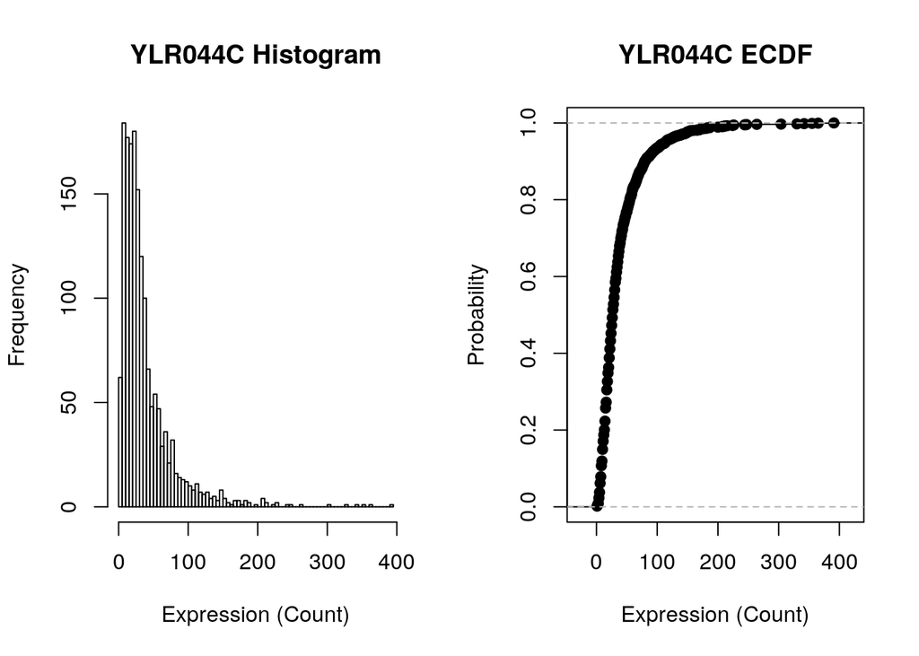

```r
# The ecdf() function calculates an EMPIRICAL CDF
# It returns an ECDF object
# All you need to know about that object is that plot() knows what it is and will handle it fine
ylr044c.data <- example.expression.data$YLR044C
ylr044c.ecdf <- ecdf(ylr044c.data)

# Lets plot the histogram against the ECDF
par(mfrow=c(1,2))
hist(ylr044c.data, main="YLR044C Histogram", breaks = 100, xlab="Expression (Count)")
plot(ylr044c.ecdf, main = "YLR044C ECDF", xlab="Expression (Count)", ylab="Probability")
```

Yep, that’s data. Just like it was last week. This week we’re going to fit the negative binomial to this distribution.

```r
nbinom.fit <- MASS::fitdistr(example.expression.data$YLR044C, densfun = "negative binomial")
nbinom.fit
```

```
##       size           mu
##    1.52112124   38.86192217
##  ( 0.05088163) ( 0.79218905)
```

What is mu? It’s just size & probability combined into a new parameter. I hate it. Lets recalculate `prob` from mu. We can put it in the same data structure that holds everything else

```r
calc.prob <- function(fitdistr.result) {fitdistr.result$estimate['size']/(fitdistr.result$estimate['size']+fitdistr.result$estimate['mu'])}
nbinom.fit$estimate['prob'] <- calc.prob(nbinom.fit)
```

How stable is this estimate for probability? Lets figure it out with SAMPLING.

```r
p.samples <- list()
num.resampling <- 10
sample.size <- 500

for (i in 1:num.resampling) {
  loop.sample <- example.expression.data$YLR044C[sample(nrow(example.expression.data), replace=T)]
  loop.fit <- MASS::fitdistr(loop.sample, densfun = "negative binomial")
  p.samples <- c(p.samples, calc.prob(loop.fit))
}
```

Neat. Lets plot this as a histogram.

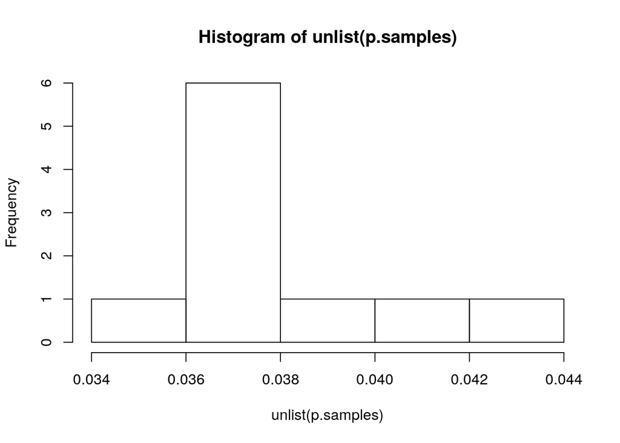

```r
hist(unlist(p.samples))
```

Well this plot is just garbage. Lets just use `ggplot`

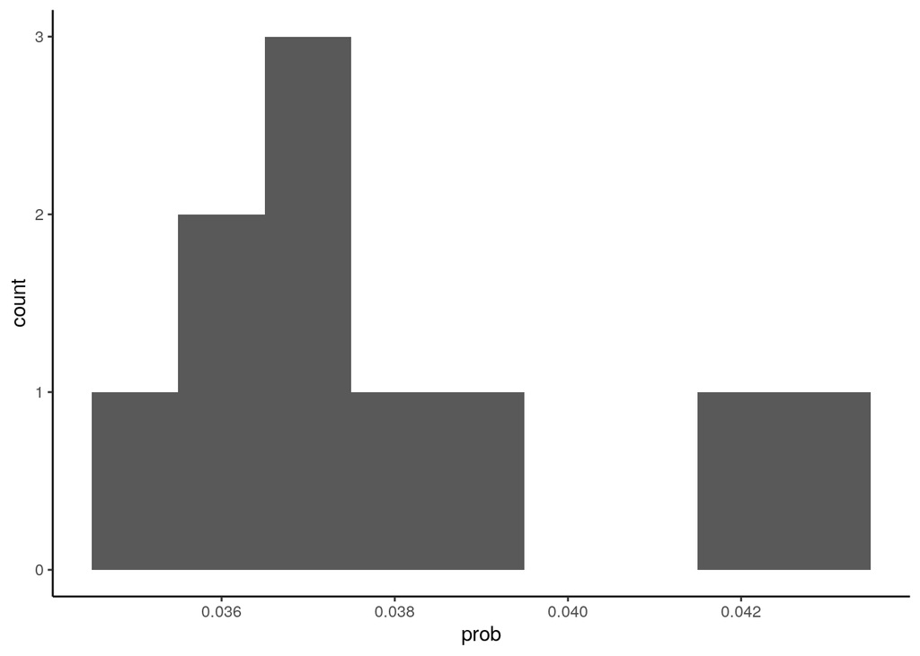

```r
p.samples <- data.frame(prob = unlist(p.samples))

ggplot(p.samples, aes(x=prob)) +
  geom_histogram(binwidth = 0.001) +
  theme_classic()
```

That is instantly less bad as a plot. Still though this looks pretty bad - lets try adding more samples

```r
p.samples <- list()
num.resampling <- 100
sample.size <- 500

for (i in 1:num.resampling) {
  loop.sample <- example.expression.data$YLR044C[sample(nrow(example.expression.data), replace=T)]
  loop.fit <- MASS::fitdistr(loop.sample, densfun = "negative binomial")
  p.samples <- c(p.samples, calc.prob(loop.fit))
}
```

And the plot:

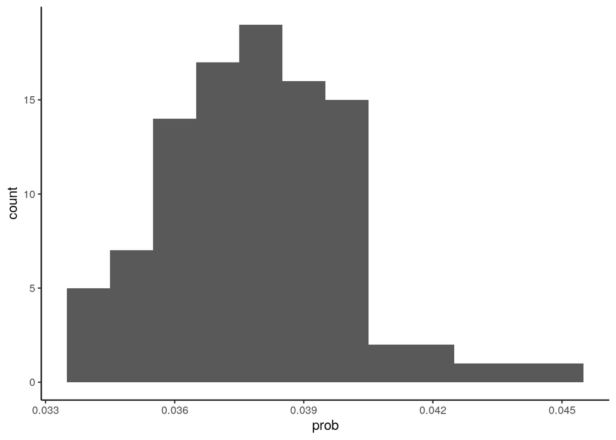

```r
p.samples <- data.frame(prob = unlist(p.samples))

ggplot(p.samples, aes(x=prob)) +
  geom_histogram(binwidth = 0.001) +
  theme_classic()
```

Break into 3 groups and use the data provided to:

1. Load and look breifly at the structure of your data
2. Fit the negative binomial to each of 3 genes
3. Resample and plot the estimates of size and probability